# Computational Reproducibility

What makes computational communication science (ir)reproducible?

Johannes B. Gruber, Tim Schatto-Eckrodt, Chung-hong Chan

Universiteit van Amsterdam, Universität Hamburg, GESIS

2023-10-05

## Computational Communication Science

> the endeavor to understand human communication by developing and applying digital tools that often involve a high degree of automation in observational, theoretical, and experimental research.

[Hilbert et al. (2019)](https://ijoc.org/index.php/ijoc/article/view/10675)

## Computational *Social* Science

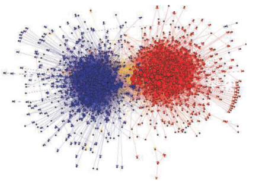

Adamic & Glance (2005)

## Communication Science

> Whatever piece of scholarship finds room in **communication associations, journals,** departments, and schools is communication research.

Waisbord (2019) - *Communication: A Post-Discipline*

## *Computational Communication Research* (I/II)

[figure not shown]

[figure not shown]

## *Computational Communication Research* (II/II)

> CCR demands transparent and reproducible research. … As digital data and analysis code can be shared easily, computational research can be at the forefront of the open science philosophy … Most articles in CCR should be accompanied by an online appendix in a form that encourages **reproducibility** and reusability.

[Van Atteveldt et al. (2019)](https://doi.org/10.5117/CCR2019.1.001.VANA)

## Question

Really?

## “Subjects” and method

- “Snapshot” date: 2023-05-25
- All articles with empirical analyses published in *CCR* up to this date: 30
- Preregistered **the criteria for reproducibility**
- Code execution (+/- code rewrite)
- “Postmortem analysis”

## Computational reproducibility

> A result is reproducible when the **same analysis** (1) steps performed on the **same dataset** (2) **consistently produce the same answer** (3). This reproducibility of the result **can be checked** (4) by the original investigators and other researchers within a local computational environment.

[Schoch, Chan, Wagner, & Bleier. (2023)](https://doi.org/10.48550/arXiv.2307.01918)

## Operationalization: Preregistered criteria for failure

1. **No shared code** (Not the same analysis)
2. **No shared data** (Not the same dataset)
3. **Code execution failure, despite code rewrite** (Uncheckability for consistency)
4. **Technically executable, but results with major deviations** (Not the same answer)

## Let’s make a guess now

*CCR* papers are computationally reproducible.

? / 30

## Code and Data archive

- Archive data and code from OSF on the Snapshot date
- Github: Clone the repo up to the last commit before the Snapshot date

## Code execution environment

- Docker container
- Rocker `rver` + an optional Python `pyenv` layer
- R 4.3.0 and Python 3.11.3 (Snapshot date)

## Dependencies

- Code scanning for dependencies: `renv` (R) and `pipreqs` (Python)
- Installation: Posit Public Package Manager (set to Snapshot date)

## Code execution

- **Allow rewrite**
- Patch the code by either `sed` or `patch`
- **Batch execution** via a single `bash` script inside the container

```bash
git init
git remote add origin https://github.com/xxx/yyy
git fetch
git checkout ed5bd12a590b06e9a32058fe2eec57f38cd3f1e2

Rscript install_dependencies.r

unzip Docs.zip

mkdir Data ## undocumented

## Code execution
Rscript 01_data_processing.R
bash 02_glove.sh
Rscript 03_dictionary_generation.R
##04 hardcoded the plan; and multisession is dep
sed -i 's/multiprocess/multicore/' 04_sentiment_validation.R
Rscript 04_sentiment_validation.R
Rscript 05_sentiment_scoring.R

cp -r Data /usr/local/src/output
```

## Postmortem analysis

- **Minor deviations:**

> deviations in the decimals or obvious typographical errors

[Crüwell et al. (2023)](http://dx.doi.org/10.1177/09567976221140828)

- **Major deviations:** deviations beyond minor

## Qualitative Analysis

- Document what makes computational communication science (ir)reproducible.

## Results

Criteria 1 and 2

- 13 no shared code (12 also no shared data)
- 3 shared code but no data

## Current result

14 / 30

A B C D E F G H I J K L M N

Articles with code and data

B E G H J M N

Articles which the provided code can be executed

B E H J M N

Articles which produce the same answer

## Final answer

6 / 30

**B**

**E**

**H**

**J**

**M**

**N**

**B** (Major code rewrite, missing data for an analysis in the appendix)

**E** (Minor code rewrite)

**H** (Major code rewrite)

**J** (Major code rewrite)

**M** (No code rewrite, run for a month)

**N** (Minor code rewrite, missing data for an analysis in the appendix)

**B** (Major code rewrite, missing data for an analysis in the appendix)

**E** (Minor code rewrite)

**H** (Major code rewrite)

**J** (Major code rewrite)

**M** (No code rewrite, run for a month)

**N** (Minor code rewrite, missing data for an analysis in the appendix)

## Irreproducible

- **Incomplete sharing of data**
- **Social media data antics**
- **Incomplete sharing of code**
- Code quality issue
- Insufficient documentation
- Undocumented computational environment

## Reproducible

- Research compendium
  - Documentation, computational environment etc.
- Sequential execution (and check in batch)
  - `00_preprocess.R`, `01_validation.R`
  - `Makefile`, `dodo`
  - `R CMD BATCH`, `jupyter nbconvert --execute`
- Literate programming
- Reduce external dependencies

## Recommendations for the subfield

- доверяй, но проверяй
- Incentivize data and code sharing
- Protected access to sensitive data
- Standardize the computational environment

## Summary

- 6 / 30 or 1 / 30
- More than half **not** due to technical issues
- **Not** due to technical issues such as irreproducible computational environment, but incomplete sharing
- Improve research practices

[figure not shown]

Computational Reproducibility